# Pre-experiment nitrate and nitrogen gas modeling

Libby Mohr

8-9-2021

## Overview

We will be conducting a set of $^{15}$N-NO$_3$ release in 15 stream analogue mesocosms (SAMS) in order to characterize rates of assimilatory nitrate uptake and denitrification in each SAM. The purpose of this analysis is to determine a suitable set of sampling times following the isotopic release. To accomplish this objective, I’ve used the Linx II dataset to parameterize statistical models for two, first-order rate constants characterizing rates of total nitrate uptake and denitrification. I then used this relationship to produce time series of $^{15}$NO$_3$ concentrations and $^{15}$N$_{gas}$ concentrations in a SAM, while propagating the residual error and parameter uncertainty to produce prediction intervals.

## Import and Wrangle Linx II data

I begin by reading in the Linx II data. Because the first-order rate constants for total nitrate uptake and denitrification are given with dimensions of [L$^{-1}$], it is necessary to multiply by stream velocity to get a time-based rate constant (which is desirable for our circular flumes). Then, because the change in solute concentration for a given streambed demand depends on water depth, I re-scaled the first-order rate constants by multiplying by the depth of the stream (to get an uptake velocity), and then by dividing by the depth of the SAM raceway. Finally, I calculated the natural logarithms of both first-order rate constants and nitrate concentrations, since previous work (e.g. Mulholland et al., 2008) has demonstrated a power law relationship between uptake velocity and nitrate concentrations.

```r
library(readxl)
library(tidyverse)
library(here)
linx <- read_xlsx(path = here("data", "LINXII.xlsx"),
                  sheet = "Data",
                  col_types = c(rep("text", times = 3),
                                rep("numeric", times = 10)),
                  na = "NA")

# Note: rate constants were originally given in units of m^-1, and velocities in m/min, so final
# rate constant units as calculated here are in min^-1

racewayDepth <- 0.15 # meters

linx <- linx %>%
  filter(!NO3 == 0) %>%
  mutate(ktot_norm = ktot * Velocity * Depth/racewayDepth,
         kden_norm = kden * Velocity * Depth/racewayDepth) %>%
  mutate(ku_norm = ktot_norm - kden_norm) %>%
  mutate(ku_norm_log = log(ku_norm),
         kden_norm_log = log(kden_norm),
         ktot_norm_log = log(ktot_norm),
         NO3_log = log(NO3))
```

## Estimate Parameters

Here, I estimate parameters for two simple linear models:
$$log(k_{tot}) = \beta_0 + \beta_1log([NO_3^{-1}]) + \epsilon$$
$$log(k_{den}) = \beta_0 + \beta_1log([NO_3^{-1}]) + \epsilon$$
where $\epsilon \sim Normal(0, \sigma^2)$

I use Just Another Gibbs Sampler (JAGS) to sample the posterior distributions of the linear regression coefficients and the precisions of both random error terms.

```r
library(rjags)
library(coda)
library(eivtools)
# Make data into a list that can be passed to JAGS
data <- list(x = linx$NO3_log, kTot = linx$ktot_norm_log, kDen = linx$kden_norm_log, n = nrow(linx))

# Specify moments for priors
data$b0 <- c(0,0)  # means for multivariate-normal linear regression coefficient prior
data$Vb <- solve(diag(10000,2)) # precisions for multivariate-normal linear regression coefficient prior
data$s1 <- 0.1  # shape parameter for gamma-distributed error prior
data$s2 <- 0.1  # scale parameter for gamma-distributed error prior

# Define model code
multivariate_regression <- "
model{

  betakTot ~ dmnorm(b0,Vb)      ## multivariate Normal prior on vector of regression params
  betakDen ~ dmnorm(b0,Vb)      ## multivariate Normal prior on vector of regression params
  preckTot ~ dgamma(s1,s2)   ## prior precision
  preckDen ~ dgamma(s1,s2)   ## prior precision

  for(i in 1:n){
      mukTot[i] <- betakTot[1] + betakTot[2]*x[i]
      kTot[i]  ~ dnorm(mukTot[i], preckTot)
      mukDen[i] <- betakDen[1] + betakDen[2]*x[i]
      kDen[i]  ~ dnorm(mukDen[i], preckDen)
  }
}"

# Specify number of chains, initial conditions
nChains = 3
inits <- list()
for(i in 1:nChains){
 inits[[i]] <- list(betakTot = rnorm(2,0,5), betakDen = rnorm(2,0,5), preckTot = runif(1,1/100,1/20), preckDen = runif(1,1/100,1/20))
}

# Create JAGS model object
jagsModel <- jags.model(file = textConnection(multivariate_regression),
                        data = data,
                        inits = inits,
                        n.chains = nChains)
```

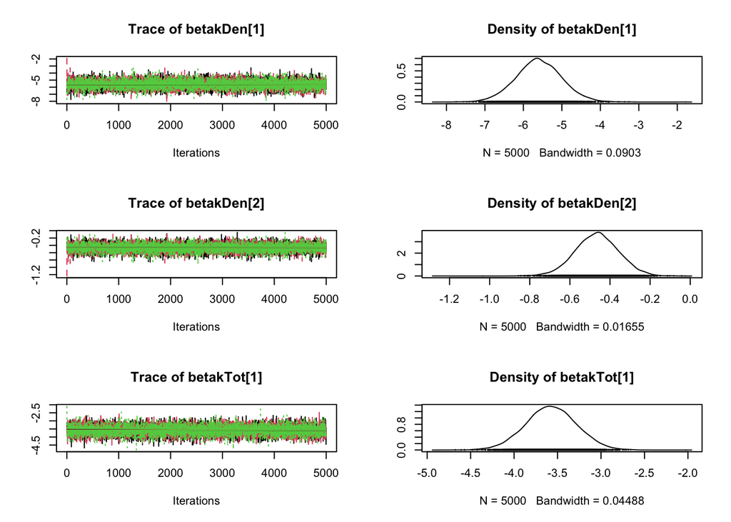

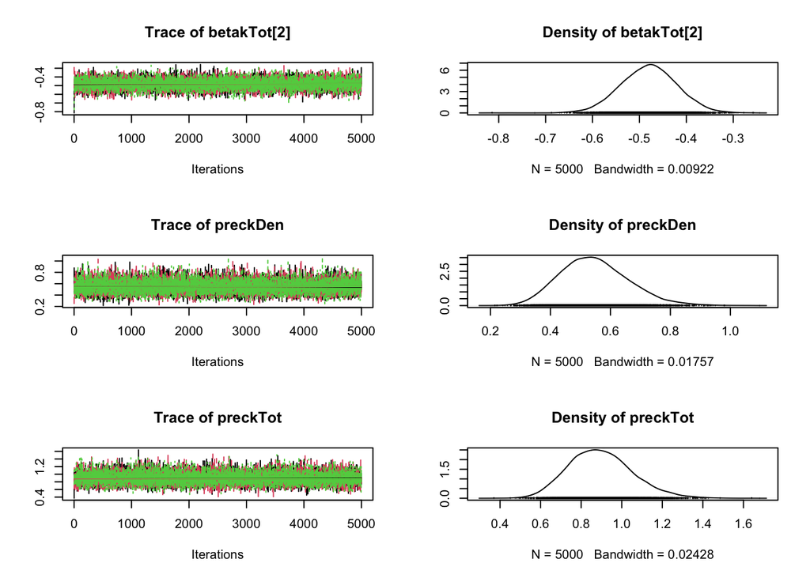

```r
# Sample posterior distribution
var.out <- coda.samples (model = jagsModel,
                         variable.names = c("betakTot", "betakDen", "preckTot", "preckDen"),
                         n.iter = 5000)

# Evaluate Model
plot(var.out)
```

```r
gelman.diag(var.out)
```

```
## Potential scale reduction factors:
##
##             Point est. Upper C.I.
## betakDen[1]          1          1
## betakDen[2]          1          1
## betakTot[1]          1          1
## betakTot[2]          1          1
## preckDen             1          1
## preckTot             1          1
##
## Multivariate psrf
##
## 1
```

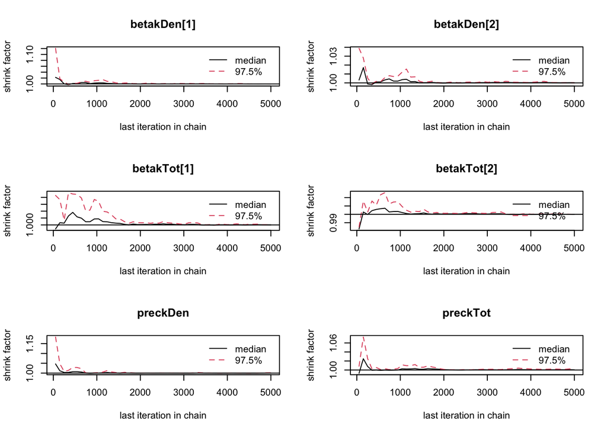

```r
GBR <- gelman.plot(var.out)
```

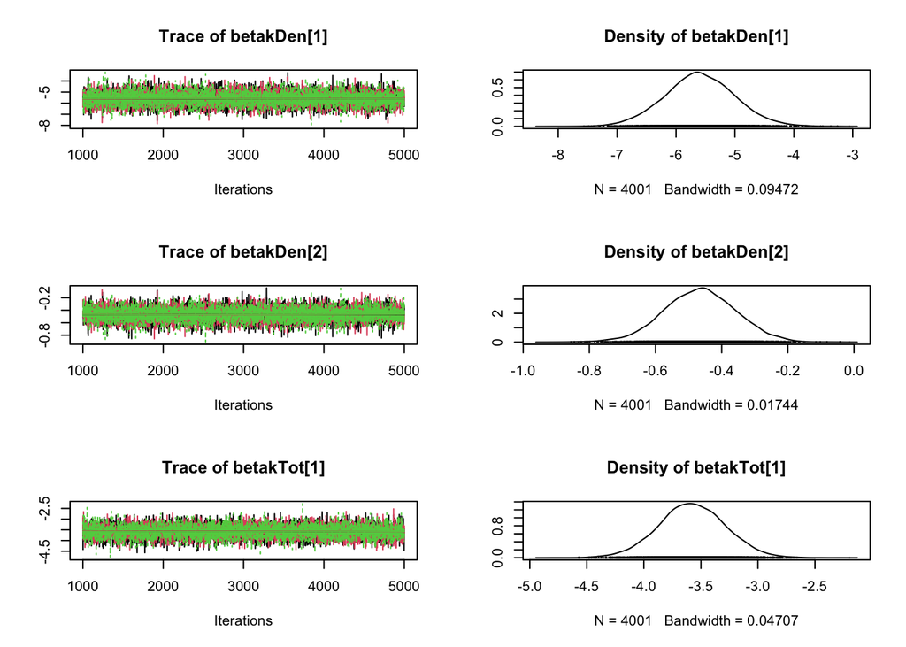

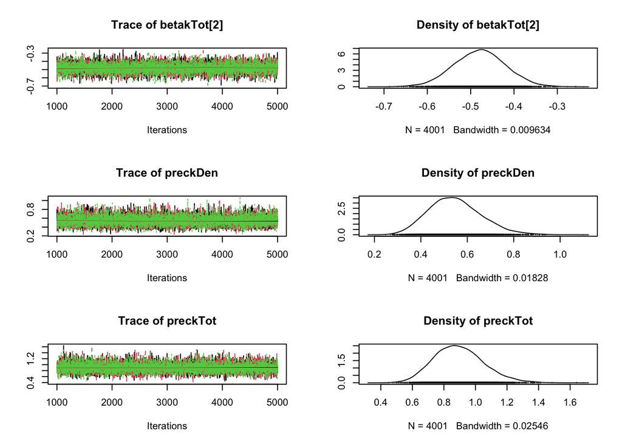

```r
# Remove burn-in
burnin = 1000
jags.burn <- window(var.out, start=burnin)
plot(jags.burn)
```

```r
# Convert output to matrix
out <- as.matrix(jags.burn)
```

## Simulate Nitrate and Nitrogen Gas Dynamics

Here I use a Monte Carlo approach to propagating uncertainty by randomly sampling rows from the MCMC output, calculating first-order rate constants based on the parameters in each row, and simulating $^{15}$N-NO$_3$ and $^{15}$N-NO$_3$ concentrations for 24 hours following an isotopic release according to a first-order kinetic model with gas exchange. I’ve run the Monte Carlo simulation for three nitrate concentrations, three levels of isotopic enrichment, and three gas exchange constants for comparison purposes.

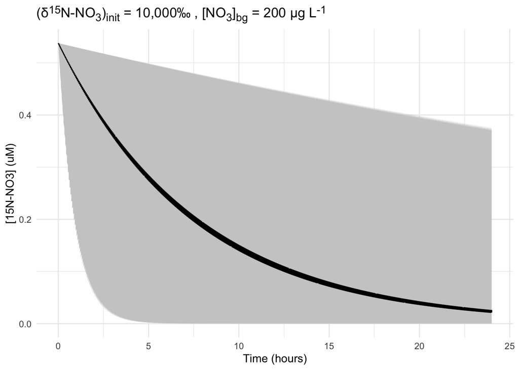

```r
library(isoToolsR)
source(here("functions", "NUptakeModels.R"))
source(here("functions", "predictionIntervals.R"))
RstN <- 0.003678 # isotope ratio of nitrogen standard
AFadd <- 0.984 # atom fraction of N15-nitrate tracer

# Specify number of realizations
n <- 5000

# Define indices to sample MCMC output
indices <- sample.int(nrow(out), n, replace = TRUE)

# Specify simulation time in minutes
times <- seq(0, 60*24, length.out = 500)

# Generate data frame of parameter combinations
NO3Pre <- c(100, 200, 300) # Nitrate concentration in SAM before isotope release
deltaNO30 <- c(5000, 10000, 20000) # Isotopic enrichment expressed as a delta value (permil)
percentTracer <- sapply(deltaNO30, calcPercentTracer, Rst = RstN, AFadd = AFadd)
NO3add <- matrix(percentTracer, nrow = 3) %*% matrix(NO3Pre, nrow = 1) # Matrix of added NO3 concentrations for each initial nitrate concentration (columns) and each level of enrichment(rows)
NO30 <- (1+matrix(percentTracer ,nrow = 3)) %*% matrix(NO3Pre, nrow = 1) # Matrix of total NO3 concentration after N15 addition for each initial nitrate concentration (columns) and each level of enrichment(rows)
N15NO30 <- AFadd * NO3add + RToAtomFrac(RstN) * matrix(rep(NO3Pre, each = length(deltaNO30)), nrow = length(deltaNO30)) # Matrix of total N15-NO3 concentration after N15 addition for each initial nitrate concentration (columns) and each level of enrichment(rows)
k2 <- c(0.001, 0.005, 0.01) # Gas exchange constants (min^-1)
params <- data.frame(
  N15NO30 = rep(as.vector(N15NO30), times = length(k2)),
  NO30 = rep(as.vector(NO30), times = length(k2)),
  NO3Pre = rep(rep(NO3Pre, each = length(deltaNO30) ), times = length(k2)),
  deltaNO30 = rep(rep(deltaNO30, times = length(NO3Pre)), times = length(k2)),
  k2 = rep(k2, each = (length(as.vector(N15NO30))))
)

# For each combination of parameters, generate ensemble of predictions for delta 15N-NGas vs. time
ensembles <- pmap(params,
                  predictN15,
                  B0Tot = out[indices,"betakTot[1]"],
                  B1Tot = out[indices,"betakTot[2]"],
                  precTot = out[indices,"preckTot"],
                  B0Den = out[indices, "betakDen[1]"],
                  B1Den = out[indices,"betakDen[2]"],
                  precDen = out[indices,"preckDen"],
                  times = times)

# Calculate median, 2.5% and 97.5% quantiles for each time
NO3PIs <- map_dfr(ensembles, getPI, times = times, varName = "N15Nitrate")
NGasPIs <- map_dfr(ensembles, getPI, times = times, varName = "N15Gas")

# Plot prediction intervals with median
library(ggtext)
k2Labs <- paste("k<sub>2</sub> = ", k2, "min<sup>-1</sup>")
names(k2Labs) <- k2
NO3PreLabs <- paste("[NO<sub>3</sub>]<sub>bg</sub> = ", NO3Pre, "&mu;g L<sup>-1</sup>")
names(NO3PreLabs) <- NO3Pre

# Convert concentrations from ug N/L to uM nitrate
NO3PIs <- NO3PIs %>%
  mutate(Median = Median/15,
         Lower = Lower/15,
         Upper = Upper/15)

# Nitrate isotopic composition plot
plotPI(NO3PIs %>% filter(delta == 10000, NO3Pre == 200)) +
  #facet_wrap(vars(NO3Pre), nrow = 1, labeller = labeller(NO3Pre = NO3PreLabs)) +
  ylab("[15N-NO3] (uM)")  +
  ggtitle("(&delta;<sup>15</sup>N-NO<sub>3</sub>)<sub>init</sub> = 10,000&permil; , [NO<sub>3</sub>]<sub>bg</sub> = 200 &mu;g L<sup>-1</sup>") +
  theme(
    strip.text = element_markdown(),
    plot.title = element_markdown()
  ) #+
```

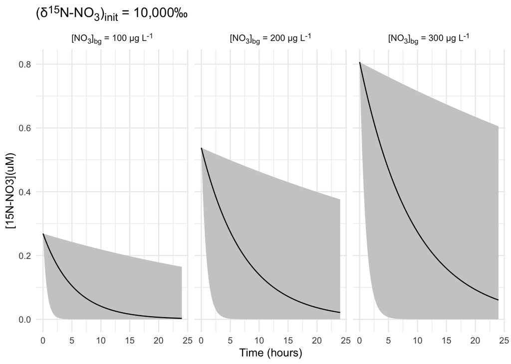

```r
  #geom_hline(yintercept = 4, color = "red")

plotPI(NO3PIs %>% filter(delta == 10000, k2 == 0.01)) +
  facet_wrap(vars(NO3Pre), nrow = 1, labeller = labeller(NO3Pre = NO3PreLabs)) +
  ylab("[15N-NO3](uM)")  +
  ggtitle("(&delta;<sup>15</sup>N-NO<sub>3</sub>)<sub>init</sub> = 10,000&permil;") +
  theme(
    strip.text = element_markdown(),
    plot.title = element_markdown()
  )
```

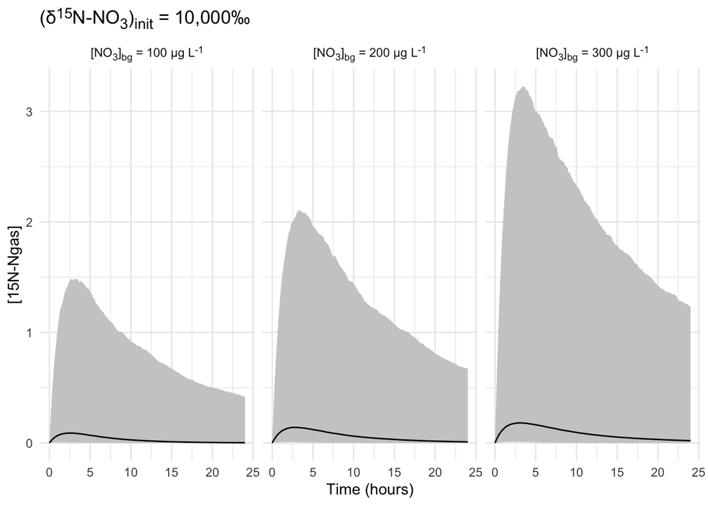

```r
# N-gas isotopic composition plots
# Compare results among background nitrate concentrations
plotPI(NGasPIs %>% filter(delta == 10000, k2 == 0.01)) +
  facet_wrap(vars(NO3Pre), labeller = labeller(NO3Pre = NO3PreLabs)) +
  ylab("[15N-Ngas]") +
  ggtitle("(&delta;<sup>15</sup>N-NO<sub>3</sub>)<sub>init</sub> = 10,000&permil;") +
  theme(
    strip.text = element_markdown(),
    strip.text.x = element_markdown(),
    strip.text.y = element_markdown(),
    plot.title = element_markdown()
  )
```

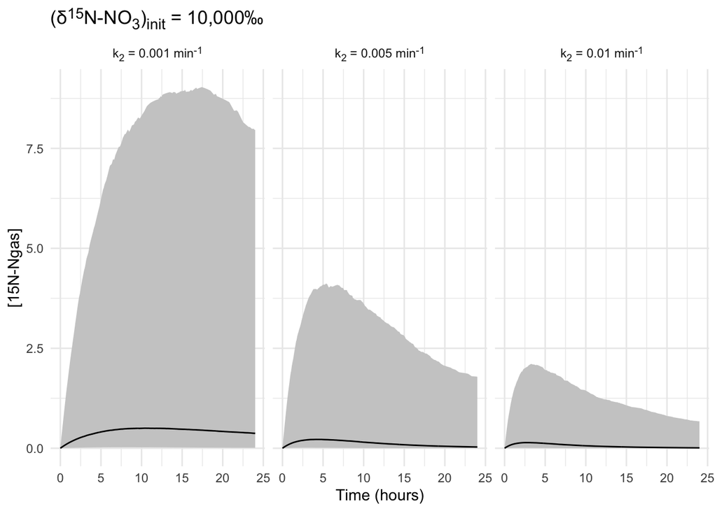

```r
# Compare results among gas exchange constants
plotPI(NGasPIs %>% filter(delta == 10000, NO3Pre == 200)) +
  facet_wrap(vars(k2), labeller = labeller(k2 = k2Labs)) +
  ylab("[15N-Ngas]") +
  ggtitle("(&delta;<sup>15</sup>N-NO<sub>3</sub>)<sub>init</sub> = 10,000&permil;") +
  theme(
    strip.text = element_markdown(),
    strip.text.x = element_markdown(),
    strip.text.y = element_markdown(),
    plot.title = element_markdown()
  )
```

## Summary of findings:

- There’s a ton of uncertainty in the rate-constants for total nitrate uptake and denitrification. This uncertainty could potentially be reduced by incorporating GPP and ER as covariates, respectively.
- The level of isotopic enrichment shouldn’t matter too much assuming we will be above the detection limit at UC Davis.
- The timing of nitrate sampling depends only on the rate of total nitrate uptake and not on background nitrate concentration, isotopic enrichment level, or gas exchange.
- The timing of denitrification sampling depends both on the rate denitrification and on the rate of gas exchange.

## Worthwhile next steps:

- Constrain gross nitrate uptake rates by estimating net nitrate uptake with measurements of mesocosm inflows and outlows.
- Constrain gross nitrate uptake rates and denitrification rates by adding additional covariates like GPP and respiration.
- Estimate gas exchange.